# Ceu_machine_learning_project

## Introduction

In this project I had to forecast store sales over 100 Rossamnn stores, based on almost three years of sales history. The company collected sales data for 1,115 Rossmann stores, including holiday, promotion, competitors etc. I selected machine learning algorithms to make precise forecast and find those factors which may affect the store sales.

# Data source

https://www.kaggle.com/c/rossmann-store-sales/data

```r
library(forecast)
library(data.table)
library(zoo)
library(arm)
library(readr)
library(dplyr)
```

```r
library(ggplot2)
library(pastecs)
library(DataCombine)
library(descr)
library(fBasics)
library(stargazer)
library(sandwich)
library(lmtest)
library(splines)
library(readr)
library(gmodels)
library(mfx)
library(descr)
library(rstan)
```

# CLEAR MEMORY

```r
rm(list = ls())
```

# SET WORKING DIRECTORY

```r
setwd("/Users/Attila/Desktop/R tool/Ceu machine learning project")
getwd()
```

```
## [1] "/Users/Attila/Desktop/R tool/Ceu machine learning project"
```

# First, load train, test, and store data.

I have separately train and test database.

```r
test <- read.csv("test.csv")
train <- read.csv("train.csv")
store <- read.csv("store.csv")
```

# Summary

```r
str(train)
```

```
## 'data.frame':    1017209 obs. of  9 variables:
##  $ Store        : int  1 2 3 4 5 6 7 8 9 10 ...
##  $ DayOfWeek    : int  5 5 5 5 5 5 5 5 5 5 ...
##  $ Date         : Factor w/ 942 levels "2013-01-01","2013-01-02",..: 942 942 942 942 942 942 942 942 942 942 ...
##  $ Sales        : int  5263 6064 8314 13995 4822 5651 15344 8492 8565 7185 ...
##  $ Customers    : int  555 625 821 1498 559 589 1414 833 687 681 ...
##  $ Open         : int  1 1 1 1 1 1 1 1 1 1 ...
##  $ Promo        : int  1 1 1 1 1 1 1 1 1 1 ...
##  $ StateHoliday : Factor w/ 4 levels "0","a","b","c": 1 1 1 1 1 1 1 1 1 1 ...
##  $ SchoolHoliday: int  1 1 1 1 1 1 1 1 1 1 ...
```

```r
str(test)
```

```
## 'data.frame':    41088 obs. of  8 variables:
##  $ Id           : int  1 2 3 4 5 6 7 8 9 10 ...
##  $ Store        : int  1 3 7 8 9 10 11 12 13 14 ...
##  $ DayOfWeek    : int  4 4 4 4 4 4 4 4 4 4 ...
##  $ Date         : Factor w/ 48 levels "2015-08-01","2015-08-02",..: 48 48 48 48 48 48 48 48 48 48 ...
##  $ Open         : int  1 1 1 1 1 1 1 1 1 1 ...
##  $ Promo        : int  1 1 1 1 1 1 1 1 1 1 ...
##  $ StateHoliday : Factor w/ 2 levels "0","a": 1 1 1 1 1 1 1 1 1 1 ...
##  $ SchoolHoliday: int  0 0 0 0 0 0 0 0 0 0 ...
```

```r
str(store)
```

```
## 'data.frame':    1115 obs. of  10 variables:
##  $ Store                    : int  1 2 3 4 5 6 7 8 9 10 ...
##  $ StoreType                : Factor w/ 4 levels "a","b","c","d": 3 1 1 3 1 1 1 1 1 1 ...
##  $ Assortment               : Factor w/ 3 levels "a","b","c": 1 1 1 3 1 1 3 1 3 1 ...
##  $ CompetitionDistance      : int  1270 570 14130 620 29910 310 24000 7520 2030 3160 ...
##  $ CompetitionOpenSinceMonth: int  9 11 12 9 4 12 4 10 8 9 ...
##  $ CompetitionOpenSinceYear : int  2008 2007 2006 2009 2015 2013 2013 2014 2000 2009 ...
##  $ Promo2                   : int  0 1 1 0 0 0 0 0 0 0 ...
##  $ Promo2SinceWeek          : int  NA 13 14 NA NA NA NA NA NA NA ...
##  $ Promo2SinceYear          : int  NA 2010 2011 NA NA NA NA NA NA NA ...
##  $ PromoInterval            : Factor w/ 4 levels "","Feb,May,Aug,Nov",..: 1 3 3 1 1 1 1 1 1 1 ...
```

The test set has 41088 rows, the train set has 1017209 rows.Store 622 has 11 missing values in the open columns. This dataset is very big to handle it that is why I reduced it.

I also recognized that the whole customers and sales column is missing from the test data.

```r
summary(train)
```

```
##      Store          DayOfWeek             Date             Sales
##  Min.   :   1.0   Min.   :1.000   2013-01-02:   1115   Min.   :    0
##  1st Qu.: 280.0   1st Qu.:2.000   2013-01-03:   1115   1st Qu.: 3727
##  Median : 558.0   Median :4.000   2013-01-04:   1115   Median : 5744
##  Mean   : 558.4   Mean   :3.998   2013-01-05:   1115   Mean   : 5774
##  3rd Qu.: 838.0   3rd Qu.:6.000   2013-01-06:   1115   3rd Qu.: 7856
##  Max.   :1115.0   Max.   :7.000   2013-01-07:   1115   Max.   :41551
##                                   (Other)   :1010519
##    Customers           Open            Promo        StateHoliday
##  Min.   :   0.0   Min.   :0.0000   Min.   :0.0000   0:986159
##  1st Qu.: 405.0   1st Qu.:1.0000   1st Qu.:0.0000   a: 20260
##  Median : 609.0   Median :1.0000   Median :0.0000   b:  6690
##  Mean   : 633.1   Mean   :0.8301   Mean   :0.3815   c:  4100
##  3rd Qu.: 837.0   3rd Qu.:1.0000   3rd Qu.:1.0000
##  Max.   :7388.0   Max.   :1.0000   Max.   :1.0000
##
##  SchoolHoliday
##  Min.   :0.0000
##  1st Qu.:0.0000
##  Median :0.0000
##  Mean   :0.1786
##  3rd Qu.:0.0000
##  Max.   :1.0000
##
```

```r
summary(test)
```

```
##        Id            Store          DayOfWeek             Date
##  Min.   :    1   Min.   :   1.0   Min.   :1.000   2015-08-01:  856
##  1st Qu.:10273   1st Qu.: 279.8   1st Qu.:2.000   2015-08-02:  856
##  Median :20544   Median : 553.5   Median :4.000   2015-08-03:  856
##  Mean   :20544   Mean   : 555.9   Mean   :3.979   2015-08-04:  856
##  3rd Qu.:30816   3rd Qu.: 832.2   3rd Qu.:6.000   2015-08-05:  856
##  Max.   :41088   Max.   :1115.0   Max.   :7.000   2015-08-06:  856
##                                                   (Other)   :35952
##       Open            Promo        StateHoliday SchoolHoliday
##  Min.   :0.0000   Min.   :0.0000   0:40908      Min.   :0.0000
##  1st Qu.:1.0000   1st Qu.:0.0000   a:  180      1st Qu.:0.0000
##  Median :1.0000   Median :0.0000                Median :0.0000
##  Mean   :0.8543   Mean   :0.3958                Mean   :0.4435
##  3rd Qu.:1.0000   3rd Qu.:1.0000                3rd Qu.:1.0000
##  Max.   :1.0000   Max.   :1.0000                Max.   :1.0000
##  NA's   :11
```

# Featuring

Combine the test and training data and clean fields, setting the date variable. Date was converted from “character” to “date”. I decrease the number of the observations.

```r
train <- train[sample(1:nrow(train), 15000, replace=FALSE),]
test <- test[sample(1:nrow(test), 5000, replace=FALSE),]

train <- train[train$Sales > 0,]
train$Id <- 0
test$Sales <- 0
test$Customers <- 0

total <- rbind(train, test)
total <- merge(total,store,by="Store")

 train$Date = as.Date(train$Date, format = "%Y-%m-%d")
 train <- train[order(train$Date),]

 test$Date = as.Date(test$Date, format = "%Y-%m-%d")
 test <- test[order(test$Date),]
```

```r
train$Promo <- as.factor(train$Promo)
train$Open <- as.factor(train$Open)
train$DayOfWeek <- as.factor(train$DayOfWeek)
train$SchoolHoliday <- as.factor(train$SchoolHoliday)



train$Month <- as.factor(format(as.Date(train$Date),"%m"))
train$Day <- as.factor(format(as.Date(train$Date),"%d"))
train$Year <- as.factor(format(as.Date(train$Date),"%Y"))
```

# First look at the data

## Examine the period

The dataset is continous. The test period ranges from 2015-08-01 to 2015-09-17, the train period ranges from 2013-01-01 to 2015-07-31.

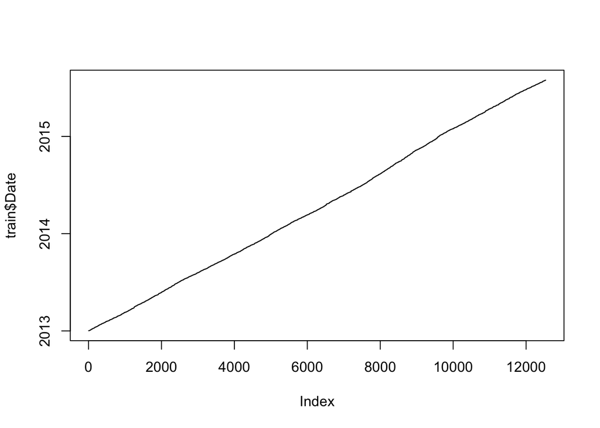

```r
plot(train$Date, type = "l")
```

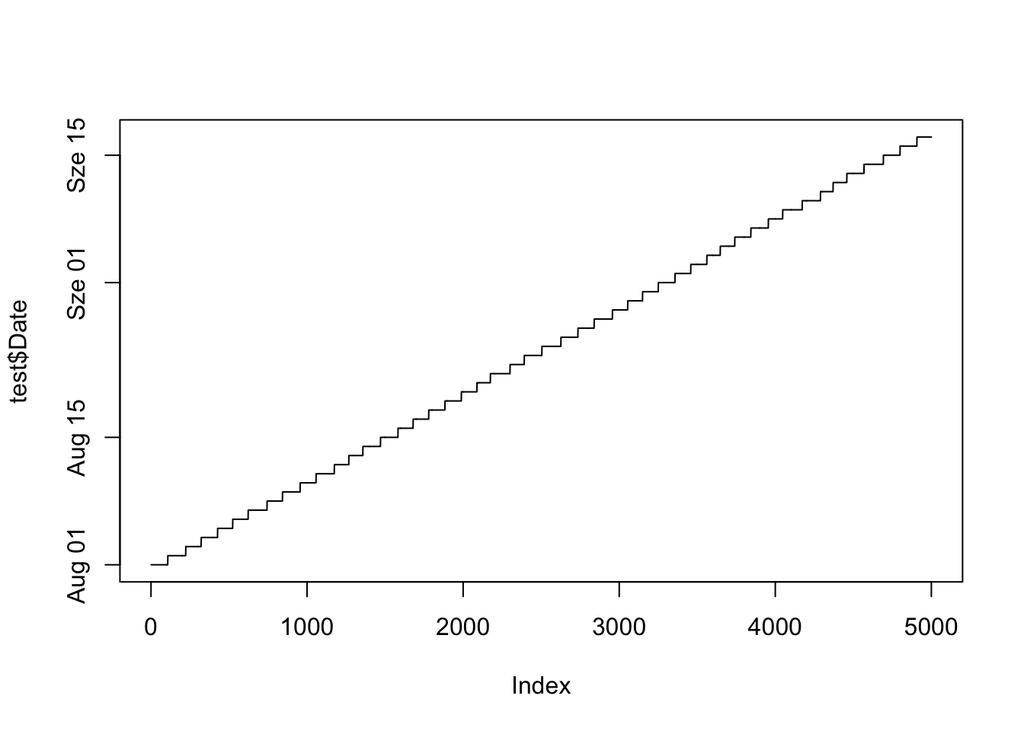

```r
plot(test$Date, type = "l")
```

## Histogram of sales

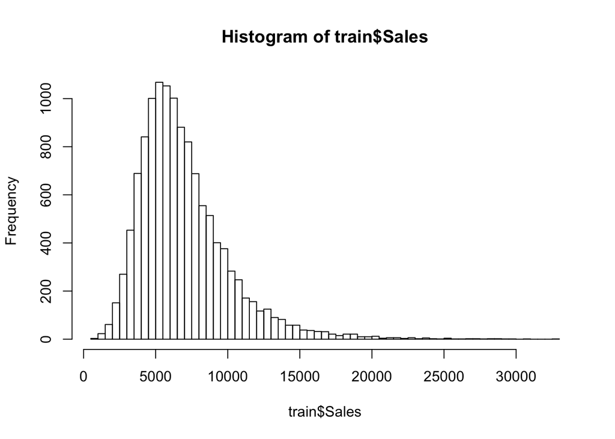

```r
hist(train$Sales, 100)
```

```r
summary(train$Sales)
```

```
##    Min. 1st Qu.  Median    Mean 3rd Qu.    Max.
##     751    4827    6326    6946    8340   32550
```

## Percent of the time promo in train

```r
table(train$Promo) / nrow(train)
```

```
##
##       0       1
## 0.55264 0.44736
```

## Percent of the time promo in test

```r
table(test$Promo) / nrow(train)
```

```
##
##         0         1
## 0.2435795 0.1552082
```

## Histogram of store competition distance

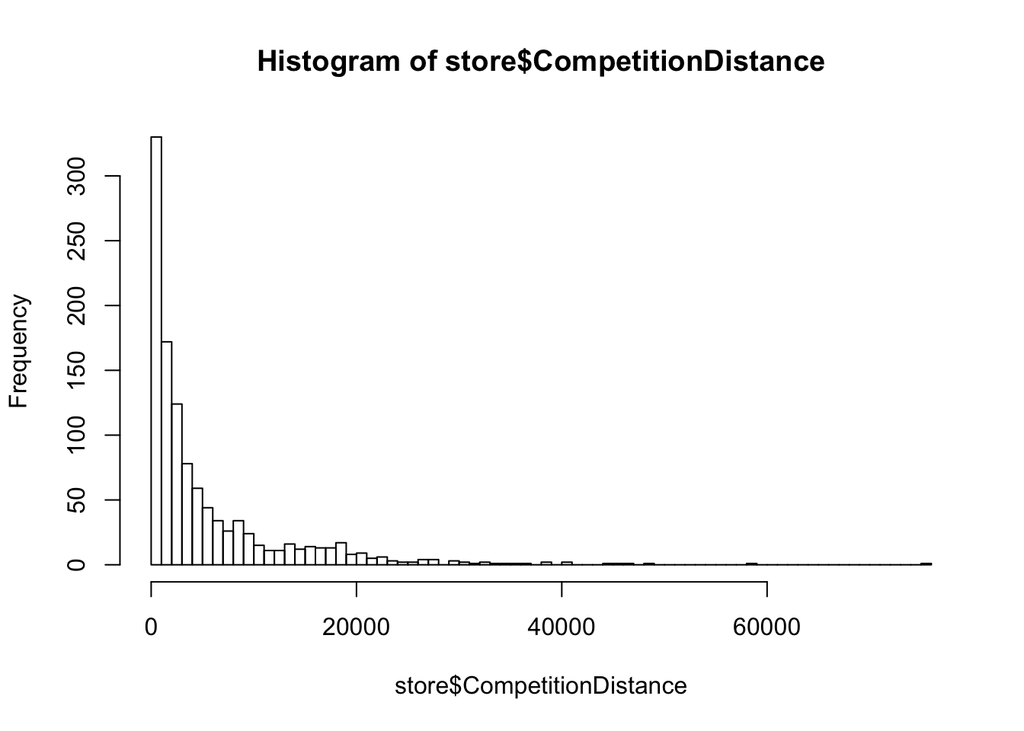

```r
hist(store$CompetitionDistance, 100)
```

## Merge the dataset with same number of variables

```r
train <- merge(train,store)
test <- merge(test,store)
```

## Exploratory data analysis

Exploratory Data Analysis (EDA), describe patterns, trends, and relationships for Rossman store date, holiday, and sales data. Provides better insight the data.

The number of stores, train, test, open, and holiday data is across all data, where promotion, sales, and customer data is only among stores that were open. If a store is closed hasn’t got promotion, or sales.

## Line diagram shows the average sales by store assortment

The different store types and assortment types imply different trends:

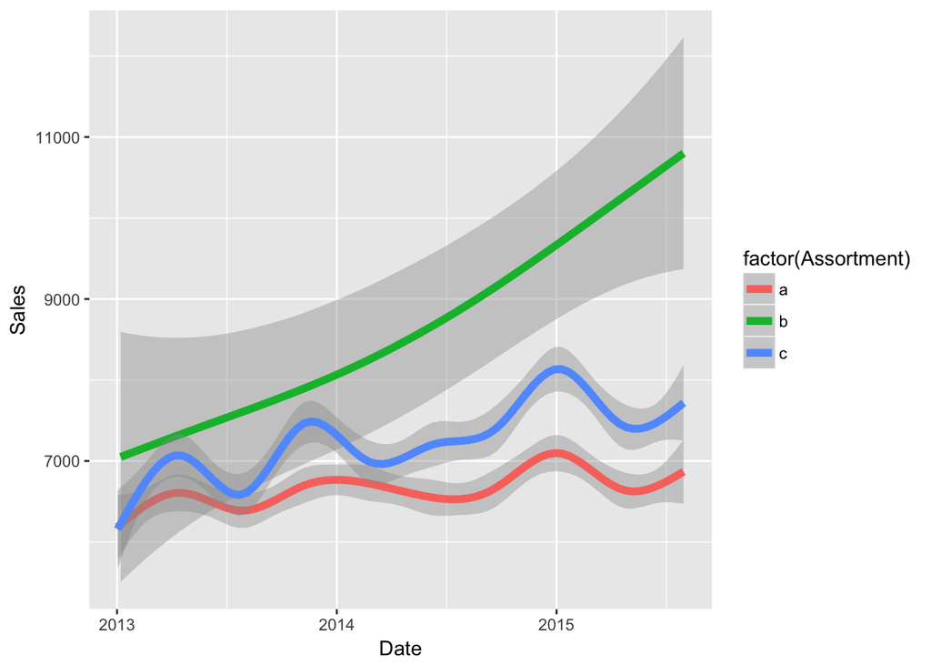

```r
ggplot(train,
       aes(x = Date, y = Sales, color = factor(Assortment))) +
    geom_smooth(size = 2)
```

## The diagram shows the distribution of number of the customers and sales

The graph shows positive correlation between the number of customers and sales. We can also find some outliers.

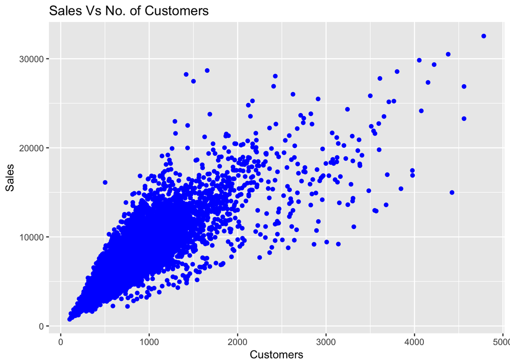

```r
  ggplot(data=train,aes(x=Customers,y=Sales)) + geom_point(color="blue") + ggtitle("Sales Vs No. of Customers")
```

## The line diagram shows the distribution of number of the customers by date

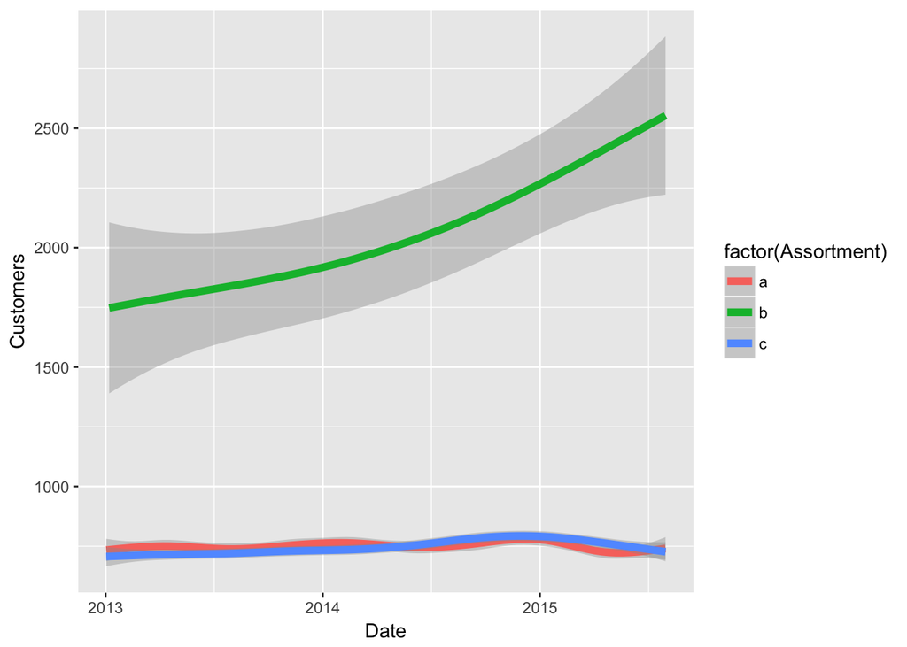

```r
ggplot(train,
       aes(x = Date, y = Customers, color = factor(Assortment))) +
    geom_smooth(size = 2)
```

## The plot diagram shows the average sales by store (based on id)

We can conlude that most of the average sales around 5000 and there are some outliers over 15000.

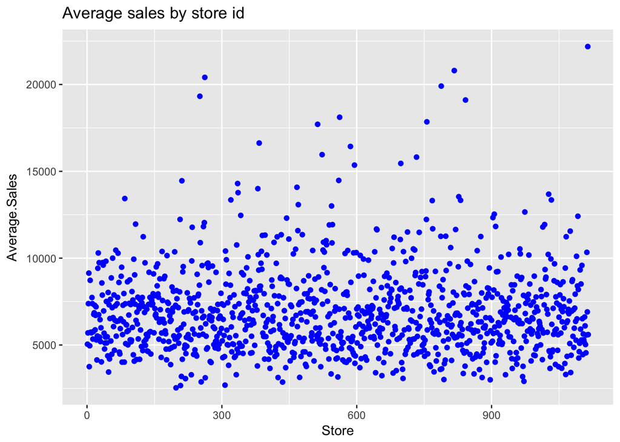

```r
sales.by.store.df <- aggregate(train$Sales,by = list(train$Store),mean)
names(sales.by.store.df) <- c("Store","Average.Sales")
ggplot(data=sales.by.store.df,aes(x=Store,y=Average.Sales)) + geom_point(color="blue") +
  ggtitle("Average sales by store id")
```

## The barchart diagram shows the average sales of the weekday

The most popular days of the week is the first and the last one in aspect of the average sales.

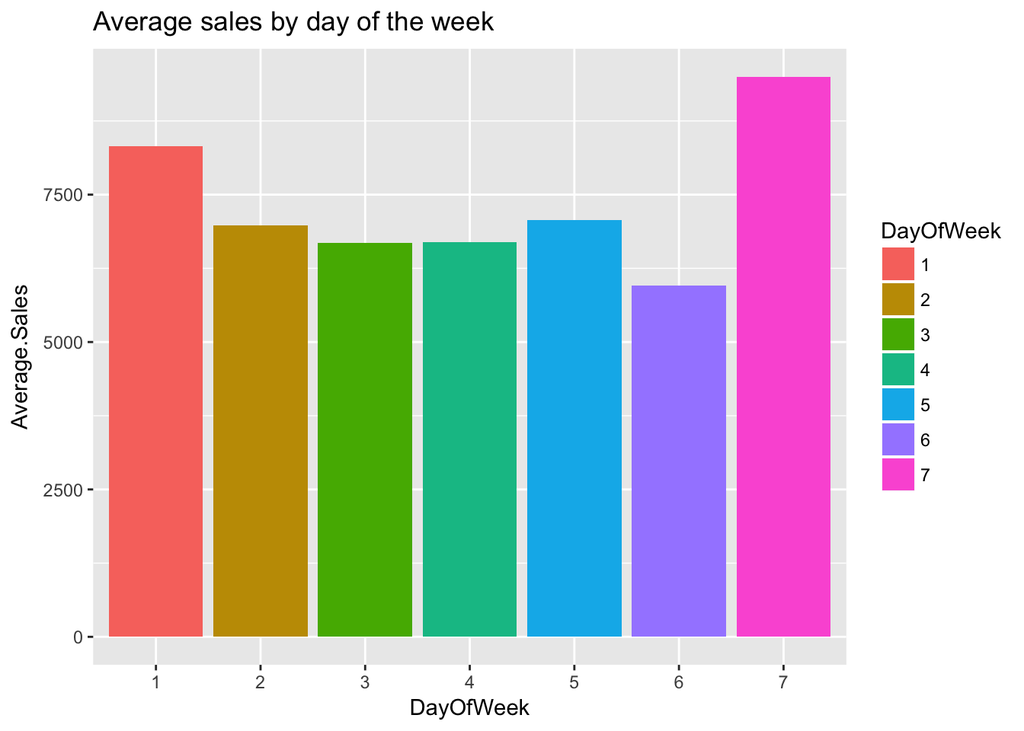

```r
sales.by.day.df <- aggregate(train$Sales,by = list(train$DayOfWeek),mean)
names(sales.by.day.df) <- c("DayOfWeek","Average.Sales")
ggplot(data=sales.by.day.df,aes(x=DayOfWeek,y=Average.Sales,fill=DayOfWeek)) +
  geom_bar(stat="identity") + ggtitle("Average sales by day of the week")
```

## The two barcharts show the average sales with promo or without promo

Based on the diargram result we can see that promo action has significant effect on average sales.

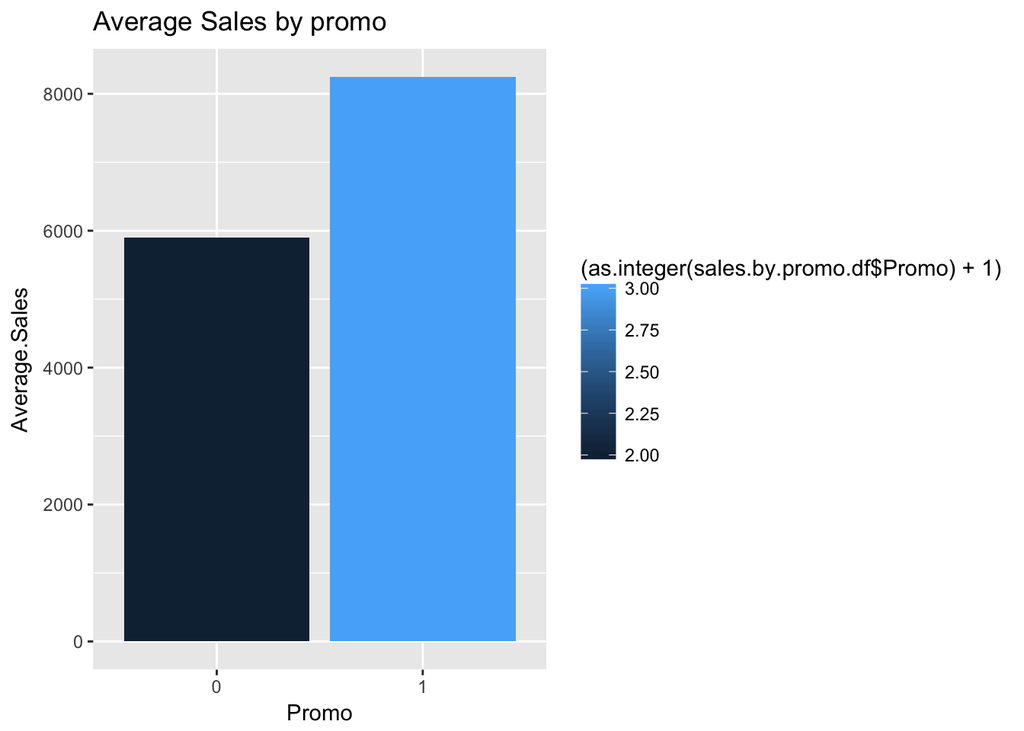

```r
sales.by.promo.df <- aggregate(train$Sales,by = list(train$Promo),function(x){mean(as.numeric(x))})
names(sales.by.promo.df) <- c("Promo","Average.Sales")
ggplot(data=sales.by.promo.df,aes(x=Promo,y=Average.Sales,fill=(as.integer(sales.by.promo.df$Promo)+1))) +
  geom_bar(stat="identity") + ggtitle("Average Sales by promo")
```

## The distribution shows the average sales of each store

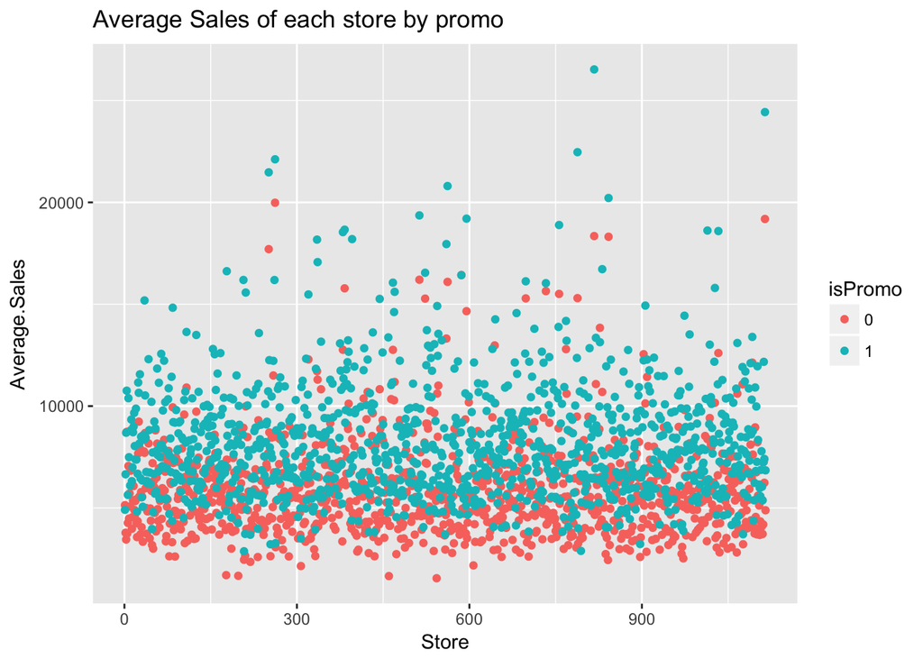

```r
sales.by.storeP.df <- aggregate(train$Sales,by = list(train$Store,train$Promo),mean)
names(sales.by.storeP.df) <- c("Store","isPromo","Average.Sales")
ggplot(data=sales.by.storeP.df,aes(Store,Average.Sales,color=isPromo)) + geom_point() +
  ggtitle("Average Sales of each store by promo")
```

## The barcharts show the average sales on school holiday

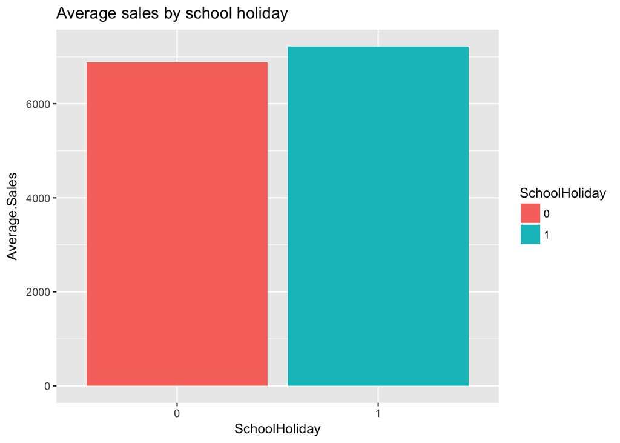

```r
sales.by.schoolH.df <- aggregate(train$Sales,by = list(train$SchoolHoliday),function(x){mean(as.numeric(x))})
names(sales.by.schoolH.df) <- c("SchoolHoliday","Average.Sales")
ggplot(data=sales.by.schoolH.df,aes(x=SchoolHoliday,y=Average.Sales,fill=SchoolHoliday)) + geom_bar(stat="identity") +
  ggtitle("Average sales by school holiday")
```

## The barcharts show the average sales by store type

Type of Store has an important role in opening patterns of stores, moreover type ‘b’ stores have comparatively higher sales.

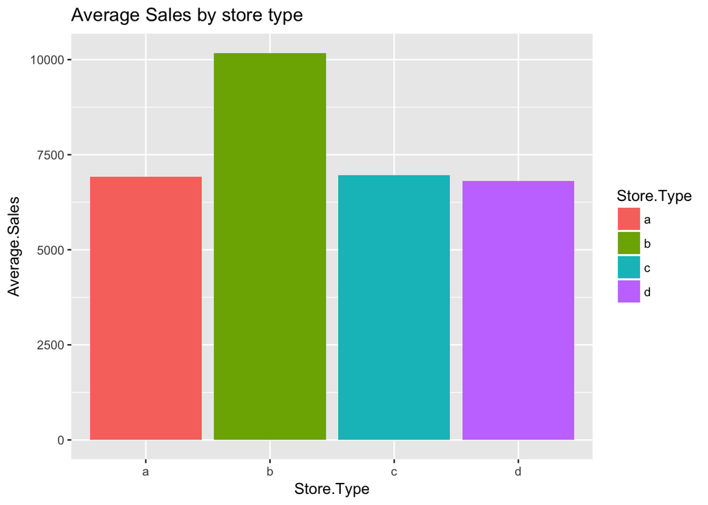

```r
sales.by.storeType.df <- aggregate(train$Sales,by = list(train$StoreType),function(x){mean(as.numeric(x))})
names(sales.by.storeType.df) <- c("Store.Type","Average.Sales")
ggplot(data=sales.by.storeType.df,aes(x=Store.Type,y=Average.Sales,fill=Store.Type)) + geom_bar(stat="identity") +
  ggtitle("Average Sales by store type")
```

## The barcharts show the average sales by assortment type

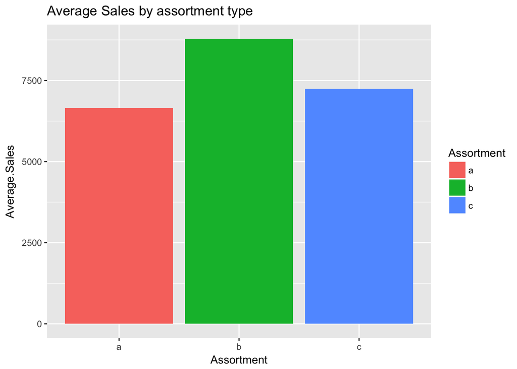

```r
sales.by.assortment.df <- aggregate(train$Sales,by = list(train$Assortment),function(x){mean(as.numeric(x))})
names(sales.by.assortment.df) <- c("Assortment","Average.Sales")
ggplot(data=sales.by.assortment.df,aes(x=Assortment,y=Average.Sales,fill=Assortment)) + geom_bar(stat="identity") +
  ggtitle("Average Sales by assortment type")
```

## The distributon shows the average sales by competiton distance

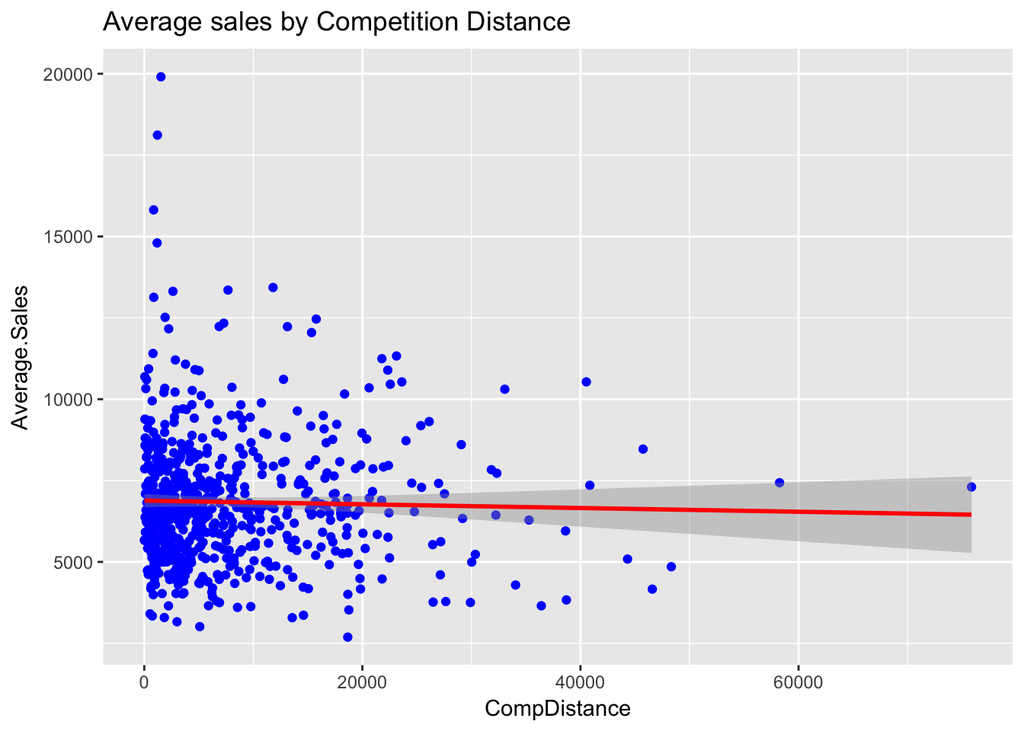

```r
sales.by.distance.df <- aggregate(train$Sales,by = list(train$CompetitionDistance),mean)
names(sales.by.distance.df) <- c("CompDistance","Average.Sales")
ggplot(data=sales.by.distance.df,aes(x=CompDistance,y=Average.Sales)) + geom_point(color="blue") +
  ggtitle("Average sales by Competition Distance") + geom_smooth(method = 'lm', color = "red")
```

```r
cor(sales.by.distance.df$CompDistance, sales.by.distance.df$Average.Sales)
```

```
## [1] -0.02562292
```

## The barcharts show the average sales by month of the year

The most popular month is december in view of the average sales.

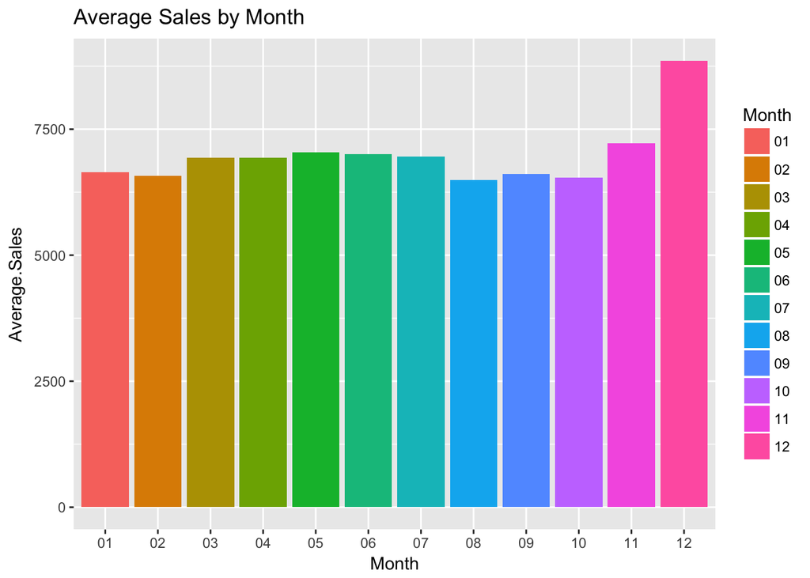

```r
sales.by.month.df <- aggregate(train$Sales,by = list(train$Month),mean)
names(sales.by.month.df) <- c("Month","Average.Sales")
ggplot(data=sales.by.month.df,aes(x=Month,y=Average.Sales,fill=Month)) + geom_bar(stat="identity") +
  ggtitle("Average Sales by Month")
```

## The barcharts show the average sales by day of the month

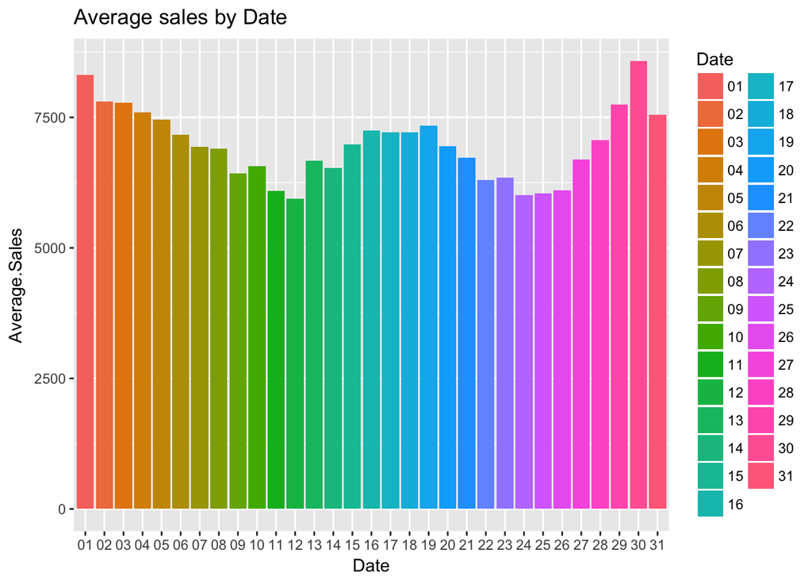

```r
sales.by.date.df <- aggregate(train$Sales,by = list(train$Day),mean)
names(sales.by.date.df) <- c("Date","Average.Sales")
ggplot(data=sales.by.date.df,aes(x=Date,y=Average.Sales,fill=Date)) + geom_bar(stat="identity") +
  ggtitle("Average sales by Date")
```

## The barcharts show the average sales by year

The distributon of the sales are almost same at the first sight between the years, however we can see a little increase year by year but it is not significant.

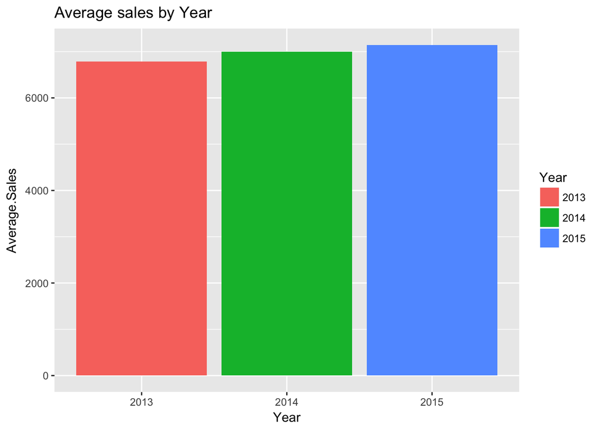

```r
sales.by.year.df <- aggregate(train$Sales,by = list(train$Year),mean)
names(sales.by.year.df) <- c("Year","Average.Sales")
ggplot(data=sales.by.year.df,aes(x=Year,y=Average.Sales,fill=Year)) + geom_bar(stat="identity") +
  ggtitle("Average sales by Year")
```

## The barcharts show the average sales per date by month

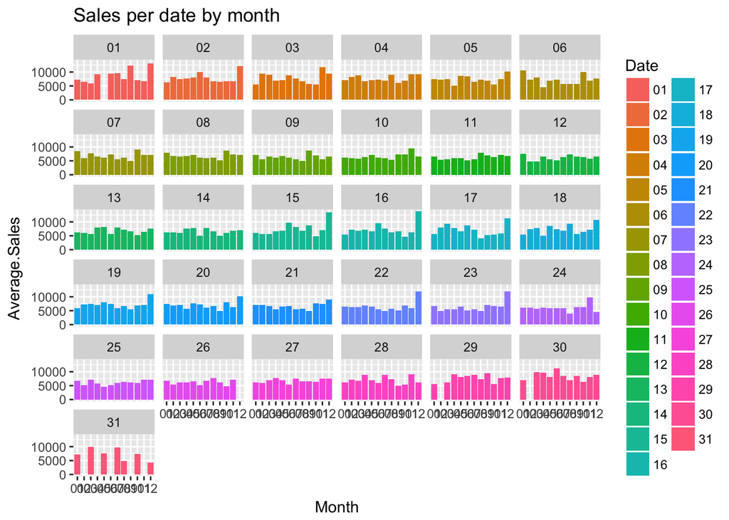

```r
sales.by.monthDay.df <- aggregate(train$Sales,by=list(train$Month,train$Day),mean)
names(sales.by.monthDay.df) <- c("Month","Date","Average.Sales")
ggplot(data=sales.by.monthDay.df,aes(Month,Average.Sales,fill=Date)) + geom_bar(stat="identity") + facet_wrap(~Date) +
  ggtitle("Sales per date by month")
```

## The barcharts show the average sales with promo on day of the week

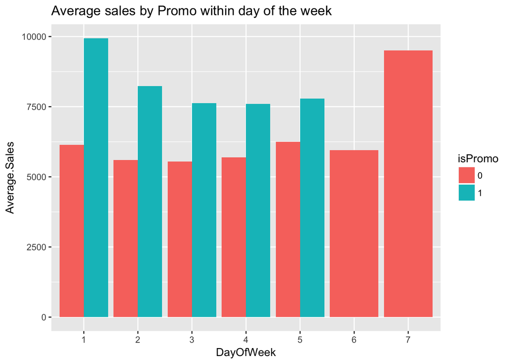

```r
sales.by.dayP.df <- aggregate(train$Sales,by = list(train$DayOfWeek,train$Promo),mean)
names(sales.by.dayP.df) <- c("DayOfWeek","isPromo","Average.Sales")
ggplot(data=sales.by.dayP.df,aes(x=DayOfWeek,y=Average.Sales,fill=isPromo)) +
  geom_bar(stat="identity",position = "dodge") + ggtitle("Average sales by Promo within day of the week")
```

# Modeling

## Random forest

Use data.table and H2O to create random forest prediction.

- The Random forest model is applied on all stores
- Sales variable is continuous
- Most of the feautures are continous

## Setup

install.packages(“h2o”)

```r
library(h2o)
h2o.init(nthreads=-1, max_mem_size='6G')
```

[output not shown]

```r
localH2O = h2o.init()
```

```
##  Connection successful!
##
## R is connected to the H2O cluster:
##     H2O cluster uptime:         3 seconds 498 milliseconds
##     H2O cluster version:        3.10.3.3
##     H2O cluster version age:    15 days
##     H2O cluster name:           H2O_started_from_R_Attila_mww391
##     H2O cluster total nodes:    1
##     H2O cluster total memory:   5.99 GB
##     H2O cluster total cores:    4
##     H2O cluster allowed cores:  4
##     H2O cluster healthy:        TRUE
##     H2O Connection ip:          localhost
##     H2O Connection port:        54321
##     H2O Connection proxy:       NA
##     R Version:                  R version 3.3.1 (2016-06-21)
```

## Further transformation

- Date feature is splitted (days, months, years)
- Train table and Store tables are merged

Observations with 0 Sales are removed to get more meaningful result. Seperating out the elements of the date column for the train set.

I choose the log transformation to not be as sensitive to high sales.

```r
cat("Formatting the datasets...\n")
```

```
## Formatting the datasets...
```

```r
train <- train[train$Sales > 0,]
train$Id <- 0
test$Sales <- 0
test$Customers <- 0



total$Date <- as.Date(as.character(total$Date), "%Y-%m-%d")
total$Year <- as.numeric(format(total$Date, "%Y"))
total$Month <- as.numeric(format(total$Date, "%m"))
total$Day <- as.numeric(format(total$Date, "%d"))
total$Open[is.na(total$Open)] <- 1
total[is.na(total)] <- -1
total$LogSales <- log1p(total$Sales)

train <- subset(total, Date < "2015-08-01")
test <- subset(total, Date >= "2015-08-01")
test$StoreType <- as.factor(test$StoreType)
train$StoreType <- as.factor(train$StoreType)

cat("Building the model...\n")
```

```
## Building the model...
```

```r
cols <- names(train)[c(1,2,7:9,11:22)]
cols
```

```
##  [1] "Store"                     "DayOfWeek"
##  [3] "Promo"                     "StateHoliday"
##  [5] "SchoolHoliday"             "StoreType"
##  [7] "Assortment"                "CompetitionDistance"
##  [9] "CompetitionOpenSinceMonth" "CompetitionOpenSinceYear"
## [11] "Promo2"                    "Promo2SinceWeek"
## [13] "Promo2SinceYear"           "PromoInterval"
## [15] "Year"                      "Month"
## [17] "Day"
```

## Load data in R

```r
trainHex<-as.h2o(train)
```

## Train a random forest

```r
rfHex <- h2o.randomForest(x=cols,
                          y="LogSales",
                          ntrees = 200, # 100
                          max_depth = 20, # 30
                          nbins_cats = 1115, ## allow it to fit store ID
                          training_frame=trainHex)
rfHex
```

```
## Model Details:
## ==============
##
## H2ORegressionModel: drf
## Model ID:  DRF_model_R_1487345184004_1
## Model Summary:
##   number_of_trees number_of_internal_trees model_size_in_bytes min_depth
## 1             200                      200            16050699        20
##   max_depth mean_depth min_leaves max_leaves mean_leaves
## 1        20   20.00000       5378       7180  6376.69000
##
##
## H2ORegressionMetrics: drf
## ** Reported on training data. **
## ** Metrics reported on Out-Of-Bag training samples **
##
## MSE:  0.0683115
## RMSE:  0.2613647
## MAE:  0.1981396
## RMSLE:  0.02689793
## Mean Residual Deviance :  0.0683115
```

```r
h2o.performance(rfHex)
```

```
## H2ORegressionMetrics: drf
## ** Reported on training data. **
## ** Metrics reported on Out-Of-Bag training samples **
##
## MSE:  0.0683115
## RMSE:  0.2613647
## MAE:  0.1981396
## RMSLE:  0.02689793
## Mean Residual Deviance :  0.0683115
```

```r
summary(rfHex)
```

```
## Model Details:
## ==============
##
## H2ORegressionModel: drf
## Model Key:  DRF_model_R_1487345184004_1
## Model Summary:
##   number_of_trees number_of_internal_trees model_size_in_bytes min_depth
## 1             200                      200            16050699        20
##   max_depth mean_depth min_leaves max_leaves mean_leaves
## 1        20   20.00000       5378       7180  6376.69000
##
## H2ORegressionMetrics: drf
## ** Reported on training data. **
## ** Metrics reported on Out-Of-Bag training samples **
##
## MSE:  0.0683115
## RMSE:  0.2613647
## MAE:  0.1981396
## RMSLE:  0.02689793
## Mean Residual Deviance :  0.0683115
##
##
##
##
##
## Scoring History:
##             timestamp   duration number_of_trees training_rmse
## 1 2017-02-17 16:26:32  0.475 sec               0
## 2 2017-02-17 16:26:33  1.548 sec               1       0.43570
## 3 2017-02-17 16:26:33  1.899 sec               2       0.41398
## 4 2017-02-17 16:26:33  2.183 sec               3       0.39489
## 5 2017-02-17 16:26:34  2.386 sec               4       0.38874
##   training_mae training_deviance
## 1
## 2      0.32104           0.18983
## 3      0.30460           0.17138
## 4      0.29205           0.15594
## 5      0.28768           0.15112
##
## ---
```

[output cut: 40 more lines]

```
## 3    0.128957
## 4    0.085095
## 5    0.080320
## 6    0.077411
## 7    0.073799
## 8    0.053066
## 9    0.037351
## 10   0.031108
## 11   0.026735
## 12   0.026688
## 13   0.026223
## 14   0.022980
## 15   0.010989
## 16   0.005520
## 17   0.001680
```

```r
h2o.mse(rfHex)
```

```
## [1] 0.0683115
```

```r
h2o.rmse(rfHex)
```

```
## [1] 0.2613647
```

```r
print(rfHex)
```

```
## Model Details:
## ==============
##
## H2ORegressionModel: drf
## Model ID:  DRF_model_R_1487345184004_1
## Model Summary:
##   number_of_trees number_of_internal_trees model_size_in_bytes min_depth
## 1             200                      200            16050699        20
##   max_depth mean_depth min_leaves max_leaves mean_leaves
## 1        20   20.00000       5378       7180  6376.69000
##
##
## H2ORegressionMetrics: drf
## ** Reported on training data. **
## ** Metrics reported on Out-Of-Bag training samples **
##
## MSE:  0.0683115
## RMSE:  0.2613647
## MAE:  0.1981396
## RMSLE:  0.02689793
## Mean Residual Deviance :  0.0683115
```

```r
cat("Predicting Sales\n")
```

```
## Predicting Sales
```

## Load test data

```r
testHex<-as.h2o(test)
h2o.mse(h2o.performance(rfHex, testHex))
```

```
## [1] 76.46729
```

```r
h2o.rmse(h2o.performance(rfHex, testHex))
```

```
## [1] 8.744558
```

## Get the results

```r
predictions<-as.data.frame(h2o.predict(rfHex,testHex))
RMSE <- sqrt(sum((predictions - test$Sales)^2)/length(predictions))
print(RMSE)
```

```
## [1] 618.3336
```

## Return the predictions to the original form

```r
pred <- expm1(predictions[,1])
summary(pred)
```

```
##    Min. 1st Qu.  Median    Mean 3rd Qu.    Max.
##    2253    5260    6202    6478    7436   22190
```

```r
submission <- data.frame(Id=test$Id, Sales=pred)
head(submission, n = 10)
```

```
##       Id    Sales
## 1  25681 6302.755
## 2  31673 4924.976
## 3   1713 6176.275
## 4      1 5884.246
## 5  21401 7556.890
## 6  22257 5568.183
## 7  24826 6995.127
## 8  11986 7073.070
## 9  18834 4908.667
## 10  4282 4186.210
```

```r
cat("saving the submission file\n")
```

```
## saving the submission file
```

```r
write.csv(submission, "h2o_rf.csv",row.names=F)
```

# GBM

```r
system.time({
  md <- h2o.gbm(x = cols, y = "LogSales",
        training_frame = trainHex, validation_frame = testHex,
        max_depth = 15, ntrees = 500, learn_rate = 0.01, nbins = 200,
        stopping_rounds = 3, stopping_tolerance = 1e-3)
})
```

```
##    user  system elapsed
##   0.206   0.007   1.430
```

## Get the results

```r
md
```

```
## Model Details:
## ==============
##
## H2ORegressionModel: gbm
## Model ID:  GBM_model_R_1487345184004_2
## Model Summary:
##   number_of_trees number_of_internal_trees model_size_in_bytes min_depth
## 1               6                        6               54898        15
##   max_depth mean_depth min_leaves max_leaves mean_leaves
## 1        15   15.00000        710        723   715.66670
##
##
## H2ORegressionMetrics: gbm
## ** Reported on training data. **
##
## MSE:  0.1709225
## RMSE:  0.4134277
## MAE:  0.322521
## RMSLE:  0.04257494
## Mean Residual Deviance :  0.1709225
##
##
## H2ORegressionMetrics: gbm
## ** Reported on validation data. **
##
## MSE:  76.56554
## RMSE:  8.750174
## MAE:  8.750145
## RMSLE:  2.277281
## Mean Residual Deviance :  76.56554
```

```r
print(md)
```

```
## Model Details:
## ==============
##
## H2ORegressionModel: gbm
## Model ID:  GBM_model_R_1487345184004_2
## Model Summary:
##   number_of_trees number_of_internal_trees model_size_in_bytes min_depth
## 1               6                        6               54898        15
##   max_depth mean_depth min_leaves max_leaves mean_leaves
## 1        15   15.00000        710        723   715.66670
##
##
## H2ORegressionMetrics: gbm
## ** Reported on training data. **
##
## MSE:  0.1709225
## RMSE:  0.4134277
## MAE:  0.322521
## RMSLE:  0.04257494
## Mean Residual Deviance :  0.1709225
##
##
## H2ORegressionMetrics: gbm
## ** Reported on validation data. **
##
## MSE:  76.56554
## RMSE:  8.750174
## MAE:  8.750145
## RMSLE:  2.277281
## Mean Residual Deviance :  76.56554
```

```r
h2o.mse(md)
```

```
## [1] 0.1709225
```

```r
h2o.rmse(md)
```

```
## [1] 0.4134277
```

```r
summary(md)
```

```
## Model Details:
## ==============
##
## H2ORegressionModel: gbm
## Model Key:  GBM_model_R_1487345184004_2
## Model Summary:
##   number_of_trees number_of_internal_trees model_size_in_bytes min_depth
## 1               6                        6               54898        15
##   max_depth mean_depth min_leaves max_leaves mean_leaves
## 1        15   15.00000        710        723   715.66670
##
## H2ORegressionMetrics: gbm
## ** Reported on training data. **
##
## MSE:  0.1709225
## RMSE:  0.4134277
## MAE:  0.322521
## RMSLE:  0.04257494
## Mean Residual Deviance :  0.1709225
##
##
## H2ORegressionMetrics: gbm
## ** Reported on validation data. **
##
## MSE:  76.56554
## RMSE:  8.750174
## MAE:  8.750145
## RMSLE:  2.277281
## Mean Residual Deviance :  76.56554
##
##
##
##
## Scoring History:
##             timestamp   duration number_of_trees training_rmse
## 1 2017-02-17 16:27:07  0.056 sec               0       0.42901
## 2 2017-02-17 16:27:07  0.247 sec               1       0.42632
## 3 2017-02-17 16:27:07  0.380 sec               2       0.42368
## 4 2017-02-17 16:27:07  0.479 sec               3       0.42106
## 5 2017-02-17 16:27:07  0.574 sec               4       0.41849
```

[output cut: 44 more lines]

```
## 3    0.148358
## 4    0.077515
## 5    0.074842
## 6    0.053195
## 7    0.042648
## 8    0.041691
## 9    0.031596
## 10   0.027113
## 11   0.024691
## 12   0.024619
## 13   0.020754
## 14   0.008204
## 15   0.003924
## 16   0.002595
## 17   0.000000
```

```r
h2o.mse(h2o.performance(md, testHex))
```

```
## [1] 76.56554
```

```r
h2o.rmse(h2o.performance(md, testHex))
```

```
## [1] 8.750174
```

```r
predictions2<-as.data.frame(h2o.predict(rfHex,testHex))
RMSE <- sqrt(sum((predictions2 - test$Sales)^2)/length(predictions))
print(RMSE)
```

```
## [1] 618.3336
```

## Return the predictions to the original form

```r
pred <- expm1(predictions[,1])
summary(pred)
```

```
##    Min. 1st Qu.  Median    Mean 3rd Qu.    Max.
##    2253    5260    6202    6478    7436   22190
```

```r
submission <- data.frame(Id=test$Id, Sales=pred)
head(submission, n = 10)
```

```
##       Id    Sales
## 1  25681 6302.755
## 2  31673 4924.976
## 3   1713 6176.275
## 4      1 5884.246
## 5  21401 7556.890
## 6  22257 5568.183
## 7  24826 6995.127
## 8  11986 7073.070
## 9  18834 4908.667
## 10  4282 4186.210
```

```r
cat("saving the submission file\n")
```

```
## saving the submission file
```

```r
write.csv(submission, "h2o_gbm.csv",row.names=F)
```

# Another approach to a prediction -> XGBoost

Building up the whole dataset for xgboost. XGBoos is an optimized distributed gradient boosting method which uses gradient boosting framework.

```r
rm(list = ls())
library(readr)
library(xgboost)
```

## Load the data

```r
cat("reading the train and test data\n")
```

```
## reading the train and test data
```

```r
train <- read_csv("train.csv")
test  <- read_csv("test.csv")
store <- read_csv("store.csv")
train <- train[sample(1:nrow(train), 15000, replace=FALSE),]
test <- test[sample(1:nrow(test), 5000, replace=FALSE),]
```

# Featuring

## Removing the date column

```r
train <- merge(train,store)
test <- merge(test,store)


train[is.na(train)]   <- 0
test[is.na(test)]   <- 0

cat("train data column names and details\n")
```

```
## train data column names and details
```

```r
names(train)
```

```
##  [1] "Store"                     "DayOfWeek"
##  [3] "Date"                      "Sales"
##  [5] "Customers"                 "Open"
##  [7] "Promo"                     "StateHoliday"
##  [9] "SchoolHoliday"             "StoreType"
## [11] "Assortment"                "CompetitionDistance"
## [13] "CompetitionOpenSinceMonth" "CompetitionOpenSinceYear"
## [15] "Promo2"                    "Promo2SinceWeek"
## [17] "Promo2SinceYear"           "PromoInterval"
```

```r
str(train)
```

```
## 'data.frame':    15000 obs. of  18 variables:
##  $ Store                    : int  1 1 1 1 1 1 1 1 1 1 ...
##  $ DayOfWeek                : int  3 1 3 4 6 1 1 4 6 1 ...
##  $ Date                     : Date, format: "2014-11-19" "2013-07-22" ...
##  $ Sales                    : int  3894 4149 5161 0 4400 4249 7675 4053 6119 5893 ...
##  $ Customers                : int  494 493 560 0 550 568 840 486 743 601 ...
##  $ Open                     : int  1 1 1 0 1 1 1 1 1 1 ...
##  $ Promo                    : int  0 0 1 0 0 0 1 0 0 1 ...
##  $ StateHoliday             : num  0 0 0 0 0 0 0 0 0 0 ...
##  $ SchoolHoliday            : int  0 1 0 1 0 0 0 1 0 0 ...
##  $ StoreType                : chr  "c" "c" "c" "c" ...
##  $ Assortment               : chr  "a" "a" "a" "a" ...
##  $ CompetitionDistance      : num  1270 1270 1270 1270 1270 1270 1270 1270 1270 1270 ...
##  $ CompetitionOpenSinceMonth: num  9 9 9 9 9 9 9 9 9 9 ...
##  $ CompetitionOpenSinceYear : num  2008 2008 2008 2008 2008 ...
##  $ Promo2                   : int  0 0 0 0 0 0 0 0 0 0 ...
##  $ Promo2SinceWeek          : num  0 0 0 0 0 0 0 0 0 0 ...
##  $ Promo2SinceYear          : num  0 0 0 0 0 0 0 0 0 0 ...
##  $ PromoInterval            : chr  "0" "0" "0" "0" ...
```

```r
summary(train)
```

```
##      Store          DayOfWeek          Date                Sales
##  Min.   :   1.0   Min.   :1.000   Min.   :2013-01-01   Min.   :    0
##  1st Qu.: 276.0   1st Qu.:2.000   1st Qu.:2013-08-18   1st Qu.: 3710
##  Median : 558.0   Median :4.000   Median :2014-03-31   Median : 5722
##  Mean   : 556.1   Mean   :4.016   Mean   :2014-04-08   Mean   : 5764
##  3rd Qu.: 833.0   3rd Qu.:6.000   3rd Qu.:2014-12-08   3rd Qu.: 7859
##  Max.   :1115.0   Max.   :7.000   Max.   :2015-07-31   Max.   :31311
##    Customers           Open            Promo         StateHoliday
##  Min.   :   0.0   Min.   :0.0000   Min.   :0.0000   Min.   :0
##  1st Qu.: 404.0   1st Qu.:1.0000   1st Qu.:0.0000   1st Qu.:0
##  Median : 609.0   Median :1.0000   Median :0.0000   Median :0
##  Mean   : 632.5   Mean   :0.8323   Mean   :0.3815   Mean   :0
##  3rd Qu.: 834.0   3rd Qu.:1.0000   3rd Qu.:1.0000   3rd Qu.:0
##  Max.   :4464.0   Max.   :1.0000   Max.   :1.0000   Max.   :0
##  SchoolHoliday    StoreType          Assortment        CompetitionDistance
##  Min.   :0.000   Length:15000       Length:15000       Min.   :    0
##  1st Qu.:0.000   Class :character   Class :character   1st Qu.:  700
##  Median :0.000   Mode  :character   Mode  :character   Median : 2300
##  Mean   :0.179                                         Mean   : 5291
##  3rd Qu.:0.000                                         3rd Qu.: 6540
##  Max.   :1.000                                         Max.   :75860
##  CompetitionOpenSinceMonth CompetitionOpenSinceYear     Promo2
##  Min.   : 0.000            Min.   :   0             Min.   :0.0000
##  1st Qu.: 0.000            1st Qu.:   0             1st Qu.:0.0000
##  Median : 4.000            Median :2006             Median :1.0000
##  Mean   : 4.946            Mean   :1370             Mean   :0.5034
##  3rd Qu.: 9.000            3rd Qu.:2011             3rd Qu.:1.0000
##  Max.   :12.000            Max.   :2015             Max.   :1.0000
##  Promo2SinceWeek Promo2SinceYear PromoInterval
##  Min.   : 0.00   Min.   :   0    Length:15000
##  1st Qu.: 0.00   1st Qu.:   0    Class :character
##  Median : 1.00   Median :2009    Mode  :character
##  Mean   :11.81   Mean   :1013
##  3rd Qu.:22.00   3rd Qu.:2012
##  Max.   :50.00   Max.   :2015
```

```r
cat("test data column names and details\n")
```

```
## test data column names and details
```

```r
names(test)
```

```
##  [1] "Store"                     "Id"
##  [3] "DayOfWeek"                 "Date"
##  [5] "Open"                      "Promo"
##  [7] "StateHoliday"              "SchoolHoliday"
##  [9] "StoreType"                 "Assortment"
## [11] "CompetitionDistance"       "CompetitionOpenSinceMonth"
## [13] "CompetitionOpenSinceYear"  "Promo2"
## [15] "Promo2SinceWeek"           "Promo2SinceYear"
## [17] "PromoInterval"
```

```r
str(test)
```

```
## 'data.frame':    5000 obs. of  17 variables:
##  $ Store                    : int  1 1 1 1 1 1 1 1 1 1 ...
##  $ Id                       : int  40233 3425 20545 28249 35953 9417 6849 18833 10273 14553 ...
##  $ DayOfWeek                : int  6 7 1 6 4 7 3 3 6 1 ...
##  $ Date                     : Date, format: "2015-08-01" "2015-09-13" ...
##  $ Open                     : int  1 0 1 1 1 0 1 1 1 1 ...
##  $ Promo                    : int  0 0 0 0 1 0 0 0 0 1 ...
##  $ StateHoliday             : num  0 0 0 0 0 0 0 0 0 0 ...
##  $ SchoolHoliday            : int  1 0 1 1 1 0 0 1 0 1 ...
##  $ StoreType                : chr  "c" "c" "c" "c" ...
##  $ Assortment               : chr  "a" "a" "a" "a" ...
##  $ CompetitionDistance      : num  1270 1270 1270 1270 1270 1270 1270 1270 1270 1270 ...
##  $ CompetitionOpenSinceMonth: num  9 9 9 9 9 9 9 9 9 9 ...
##  $ CompetitionOpenSinceYear : num  2008 2008 2008 2008 2008 ...
##  $ Promo2                   : int  0 0 0 0 0 0 0 0 0 0 ...
##  $ Promo2SinceWeek          : num  0 0 0 0 0 0 0 0 0 0 ...
##  $ Promo2SinceYear          : num  0 0 0 0 0 0 0 0 0 0 ...
##  $ PromoInterval            : chr  "0" "0" "0" "0" ...
```

```r
summary(test)
```

```
##      Store              Id          DayOfWeek          Date
##  Min.   :   1.0   Min.   :    2   Min.   :1.000   Min.   :2015-08-01
##  1st Qu.: 275.0   1st Qu.:10220   1st Qu.:2.000   1st Qu.:2015-08-13
##  Median : 552.0   Median :20519   Median :4.000   Median :2015-08-25
##  Mean   : 553.7   Mean   :20528   Mean   :3.981   Mean   :2015-08-24
##  3rd Qu.: 826.0   3rd Qu.:30696   3rd Qu.:6.000   3rd Qu.:2015-09-06
##  Max.   :1115.0   Max.   :41076   Max.   :7.000   Max.   :2015-09-17
##       Open          Promo         StateHoliday SchoolHoliday
##  Min.   :0.00   Min.   :0.0000   Min.   :0     Min.   :0.000
##  1st Qu.:1.00   1st Qu.:0.0000   1st Qu.:0     1st Qu.:0.000
##  Median :1.00   Median :0.0000   Median :0     Median :0.000
##  Mean   :0.86   Mean   :0.3972   Mean   :0     Mean   :0.443
##  3rd Qu.:1.00   3rd Qu.:1.0000   3rd Qu.:0     3rd Qu.:1.000
##  Max.   :1.00   Max.   :1.0000   Max.   :0     Max.   :1.000
##   StoreType          Assortment        CompetitionDistance
##  Length:5000        Length:5000        Min.   :    0
##  Class :character   Class :character   1st Qu.:  710
##  Mode  :character   Mode  :character   Median : 2410
##                                        Mean   : 4882
##                                        3rd Qu.: 6260
##                                        Max.   :75860
##  CompetitionOpenSinceMonth CompetitionOpenSinceYear     Promo2
##  Min.   : 0.000            Min.   :   0             Min.   :0.000
##  1st Qu.: 0.000            1st Qu.:   0             1st Qu.:0.000
##  Median : 4.000            Median :2005             Median :1.000
##  Mean   : 4.416            Mean   :1265             Mean   :0.584
##  3rd Qu.: 9.000            3rd Qu.:2011             3rd Qu.:1.000
##  Max.   :12.000            Max.   :2015             Max.   :1.000
##  Promo2SinceWeek Promo2SinceYear PromoInterval
##  Min.   : 0.00   Min.   :   0    Length:5000
##  1st Qu.: 0.00   1st Qu.:   0    Class :character
##  Median : 9.00   Median :2010    Mode  :character
##  Mean   :14.29   Mean   :1175
##  3rd Qu.:31.00   3rd Qu.:2012
##  Max.   :49.00   Max.   :2015
```

- examine only stores that were open
- seperating out the elements of the date column for the train set
- seperating out the elements of the date column for the test set

```r
train <- train[ which(train$Open=='1'),]
train <- train[ which(train$Sales!='0'),]

train$month <- as.integer(format(train$Date, "%m"))
train$year <- as.integer(format(train$Date, "%y"))
train$day <- as.integer(format(train$Date, "%d"))
train <- train[,-c(3,8)]

test$month <- as.integer(format(test$Date, "%m"))
test$year <- as.integer(format(test$Date, "%y"))
test$day <- as.integer(format(test$Date, "%d"))
test <- test[,-c(4,7)]
```

## Get the results

```r
feature.names <- names(train)[c(1,2,5:19)]
cat("Feature Names\n")
```

```
## Feature Names
```

```r
feature.names
```

```
##  [1] "Store"                     "DayOfWeek"
##  [3] "Open"                      "Promo"
##  [5] "SchoolHoliday"             "StoreType"
##  [7] "Assortment"                "CompetitionDistance"
##  [9] "CompetitionOpenSinceMonth" "CompetitionOpenSinceYear"
## [11] "Promo2"                    "Promo2SinceWeek"
## [13] "Promo2SinceYear"           "PromoInterval"
## [15] "month"                     "year"
## [17] "day"
```

```r
cat("assuming text variables are categorical & replacing them with numeric ids\n")
```

```
## assuming text variables are categorical & replacing them with numeric ids
```

```r
for (f in feature.names) {
  if (class(train[[f]])=="character") {
    levels <- unique(c(train[[f]], test[[f]]))
    train[[f]] <- as.integer(factor(train[[f]], levels=levels))
    test[[f]]  <- as.integer(factor(test[[f]],  levels=levels))
  }
}

cat("train data column names after slight feature engineering\n")
```

```
## train data column names after slight feature engineering
```

```r
names(train)
```

```
##  [1] "Store"                     "DayOfWeek"
##  [3] "Sales"                     "Customers"
##  [5] "Open"                      "Promo"
##  [7] "SchoolHoliday"             "StoreType"
##  [9] "Assortment"                "CompetitionDistance"
## [11] "CompetitionOpenSinceMonth" "CompetitionOpenSinceYear"
## [13] "Promo2"                    "Promo2SinceWeek"
## [15] "Promo2SinceYear"           "PromoInterval"
## [17] "month"                     "year"
## [19] "day"
```

```r
cat("test data column names after slight feature engineering\n")
```

```
## test data column names after slight feature engineering
```

```r
names(test)
```

```
##  [1] "Store"                     "Id"
##  [3] "DayOfWeek"                 "Open"
##  [5] "Promo"                     "SchoolHoliday"
##  [7] "StoreType"                 "Assortment"
##  [9] "CompetitionDistance"       "CompetitionOpenSinceMonth"
## [11] "CompetitionOpenSinceYear"  "Promo2"
## [13] "Promo2SinceWeek"           "Promo2SinceYear"
## [15] "PromoInterval"             "month"
## [17] "year"                      "day"
```

```r
tra<-train[,feature.names]
RMPSE<- function(preds, dtrain) {
  labels <- getinfo(dtrain, "label")
  elab<-exp(as.numeric(labels))-1
  epreds<-exp(as.numeric(preds))-1
  err <- sqrt(mean((epreds/elab-1)^2))
  return(list(metric = "RMPSE", value = err))
}

nrow(train)
```

```
## [1] 12484
```

```r
h<-sample(nrow(train),10000)

dval<-xgb.DMatrix(data=data.matrix(tra[h,]),label=log(train$Sales+1)[h])
dtrain<-xgb.DMatrix(data=data.matrix(tra[-h,]),label=log(train$Sales+1)[-h])
watchlist<-list(val=dval,train=dtrain)
param <- list(  objective           = "reg:linear",
                booster = "gbtree",
                eta                 = 0.02,
                max_depth           = 10,
                subsample           = 0.9,
                colsample_bytree    = 0.7
                #num_parallel_tree   = 2
                # alpha = 0.0001,
                # lambda = 1
)

clf <- xgb.train(   params              = param,
                    data                = dtrain,
                    nrounds             = 3000, #300, #280, #125, #250, # changed from 300
                    verbose             = 0,
                   early_stopping_round    = 100,
                    watchlist           = watchlist,
                   metrics = list("rmse","auc"),
                    maximize            = FALSE,
                    feval=RMPSE
)

summary(clf)
```

```
##                 Length   Class              Mode
## handle                 1 xgb.Booster.handle externalptr
## raw             24196530 -none-             raw
## best_iteration         1 -none-             numeric
## best_ntreelimit        1 -none-             numeric
## best_score             1 -none-             numeric
## niter                  1 -none-             numeric
## call                  10 -none-             call
## params                 8 -none-             list
## callbacks              1 -none-             list
```

```r
print(clf, verbose=TRUE)
```

```
## ##### xgb.Booster
## raw: 23.1 Mb
## call:
##   xgb.train(params = param, data = dtrain, nrounds = 3000, watchlist = watchlist,
##     feval = RMPSE, verbose = 0, early_stopping_rounds = 100,
##     maximize = FALSE, metrics = list("rmse", "auc"))
## params (as set within xgb.train):
##   objective = "reg:linear", booster = "gbtree", eta = "0.02", max_depth = "10", subsample = "0.9", colsample_bytree = "0.7", metrics = "rmse", silent = "auc", objective = "1"
## xgb.attributes:
##   best_iteration = "1477"
##   best_msg = "[1478] val-RMPSE:0.294568  train-RMPSE:0.049188"
##   best_ntreelimit = "1478"
##   best_score = "0.049188221924756317"
##   niter = "1577"
## callbacks:
##   cb.early.stop(stopping_rounds = early_stopping_rounds, maximize = maximize,
##     verbose = verbose)
## niter: 1578
## best_iteration: 1478
## best_ntreelimit: 1478
## best_score: 0.04918822
```

```r
pred1 <- exp(predict(clf, data.matrix(test[,feature.names]))) -1
summary(pred1)
```

```
##    Min. 1st Qu.  Median    Mean 3rd Qu.    Max.
##    1556    4753    5968    6320    7542   21600
```

```r
submission <- data.frame(Id=test$Id, Sales=pred1)
head(submission, n=10)
```

```
##       Id    Sales
## 1  40233 5103.998
## 2   3425 4481.901
## 3  20545 5735.617
## 4  28249 5103.998
## 5  35953 4629.535
## 6   9417 4481.901
## 7   6849 4258.390
## 8  18833 4369.302
## 9  10273 5254.598
## 10 14553 7530.219
```

```r
cat("saving the submission file\n")
```

```
## saving the submission file
```

```r
write_csv(submission, "rf1.csv")

bst2 <- xgb.train(data=dval, max.depth=2, eta=1, nthread = 2, nround=2, watchlist=watchlist, objective = "reg:linear")
bst <- xgboost(data = dtrain, label=log(train$Sales+1),nrounds = 39, param, metric = "RMSE")
cv <- xgb.cv(data = dtrain, nrounds = 3, nthread = 2, nfold = 5, metrics = list("rmse"),
                  max_depth = 3, eta = 1)
print(cv)
```

```
## ##### xgb.cv 5-folds
##  iter train_rmse_mean train_rmse_std test_rmse_mean test_rmse_std
##     1       0.4014688    0.018915635      0.4059098    0.03317269
##     2       0.3604188    0.004197947      0.3671892    0.01685858
##     3       0.3483196    0.004993486      0.3599942    0.01632360
```